# 043_panet_classification_4_classes

Marco Visani

2023-01-15

# 1 TL;DR

First read `043_panet_classification_5_classes_summary.Rmd` for detailed explanation of the results and the project. We tested the same pipeline but merging 2 classes into one (Intermediate_ADM_WT and Intermediate_WT). The results are more or less similar.

Consensus clustering was run with $k=4$ clusters.

For further details or questions, please see my [GitHub](https://github.com/mvisani/PanNET_classification) page or send me an email at marco.visani@unifr.ch.

# 2 Trees and probe selection

Please read first `043_panet_classification_5_classes_summary.Rmd` for introduction and QC of the dataset.

As in the 5 classes case, we tried to optimize the number of trees and probes for computational efficiency and avoiding overfitting. If one want to reproduce the images below, please use the `11_hyper_param_tuning.R` script and set up the number of probes and trees accordingly.

In the image below, one can see that the number of trees doesn’t influence much the result of the random forest.

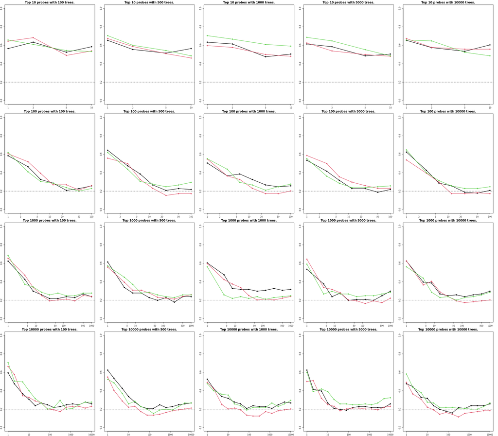

image

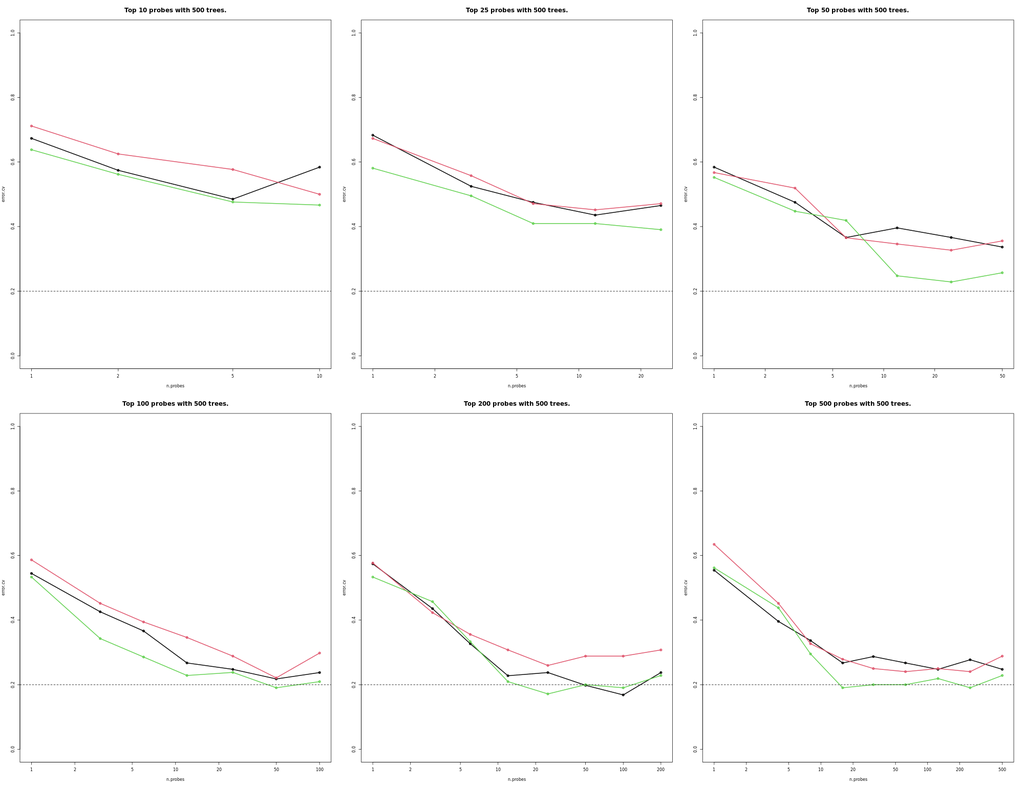

image

Same as for the 5 classes, above 100 probes, the accuracy remains the same.

# 3 Classifier cross-validation

Batch effect was NOT taken into account here !

```r
rm(list=ls())
load_file <- function(file=file){
  load(file = file, temp_env <- new.env())
  data <- as.list(temp_env)
  return(CV_result(data=data))
}

CV_result <- function(data=data){
  require(pROC)
  require(HandTill2001)
  source(file.path("scripts", "R","multi_brier.R"))
  source(file.path("scripts", "R","multi_logloss.R"))
  AUCscores <- HandTill2001::auc(multcap(response=as.factor(data$y),predicted=data$scores))
  AUCprobs <-  HandTill2001::auc(multcap(response=as.factor(data$y),predicted=data$probs))

  errs <- sum(data$y!=data$ys)/length(data$y)
  errp <- sum(data$y!=data$yp)/length(data$y)

  briers <- brier(data$scores,data$y)
  brierp <- brier(data$probs,data$y)

  logls <- mlogloss(data$scores,data$y)
  loglp <- mlogloss(data$probs,data$y)

  out <- cbind(c(AUCscores,AUCprobs),c(errs,errp),c(briers,brierp),c(logls,loglp))
  colnames(out) <- c("auc","misclassification","brier score","logloss")
  rownames(out) <- c("raw scores","calibrated scores")

  y.true <- data$y
  y.score <- data$ys
  y.calibrated <- data$yp
  return(list(AUCprobs=AUCprobs,
              AUCscores=AUCscores, errs=errs,
              errp=errp, briers=briers, brierp=brierp,
              logls=logls, loglp=loglp, out=out,
              y.true=y.true, y.score=y.score, y.calibrated=y.calibrated,
              scores=data$scores,
              probs=data$probs))
}

confusion_matrix <- function(data=data,n_probes=n_probes){
  require(pheatmap)
  require(RColorBrewer)
  require(ggplot2)
  m <-table(data$y.true, data$y.calibrated)
  m <- m/apply(m, 1, sum)

  return(
  pheatmap(m,
           display_numbers = table(data$y.true, data$y.calibrated),
           fontsize_number=15,
           fontsize_row=15,
           fontsize_col = 15,
           angle_col = 45,
           treeheight_row = 0,
           treeheight_col = 0,
           cluster_rows = F,
           cluster_cols = F,
           color=colorRampPalette(c("white", "red"))(100),
           main=paste0("Confusion matrix of top ", n_probes," probes."))
  )
}


ROC_graph <- function(data=data, n_probes=n_probes){
  require(pROC)
  require(ggplot2)
  require(RColorBrewer)
  roc_resp <- as.numeric(data$y.true!=data$y.calibrated)
  predictor_roc <- apply(data$probs, 1, max)
  roc_to_plot <- roc(response=roc_resp, predictor=predictor_roc, ci=TRUE, of="se")
  roc_with_ci <- function(obj) {
    ciobj <- obj$ci
    dat.ci <- data.frame(x = as.numeric(rownames(ciobj)),
                         lower = ciobj[, 1],
                         upper = ciobj[, 3])

    ggroc(obj, legacy.axes = T) +
      theme_minimal() +
      geom_abline(
        slope = 1,
        intercept = 0,
        linetype = "dashed",
        alpha = 0.7,
        color = "black"
      ) + coord_equal() +
      geom_ribbon(
        data = dat.ci,
        aes(x = 1-x, ymin = lower, ymax = upper),
        fill = "steelblue",
        alpha = 0.3
      ) + ggtitle(paste0("AUC of ", format(round(obj$auc, 2), nsmall = 2), " for top ", n_probes, " probes."))
  }

  return(roc_with_ci(roc_to_plot))
}

calibrated_score_plot <- function(data=data){
  require(ggplot2)
  require(ggridges)
  calibrated_score <- as.data.frame(data$probs)
  calibrated_score <- calibrated_score[data$y.true == data$y.calibrated, ]
  max <- apply(calibrated_score, 1, max)
  Classes <- colnames(calibrated_score)[apply(calibrated_score, 1, which.max)]
  calibrated_score <- cbind(calibrated_score, max)
  calibrated_score <- cbind(calibrated_score, Classes)

  # plot the raw scores
  calibrated <- ggplot(calibrated_score, aes(x = max, y = Classes, fill = Classes)) +
    xlim(0,1.2) +
    ggtitle("Calibrated scores for correctly classified cases") +
    geom_density_ridges() +
    theme_ridges() +
    theme(legend.position = "none")
  return(calibrated)
}

raw_score_plot <- function(data=data){
  require(ggplot2)
  require(ggridges)
  raw_score <- as.data.frame(data$scores)
  raw_score <- raw_score[data$y.true == data$y.score, ]
  max <- apply(raw_score, 1, max)
  Classes <- colnames(raw_score)[apply(raw_score, 1, which.max)]
  raw_score <- cbind(raw_score, max)
  raw_score <- cbind(raw_score, Classes)

  # plot the raw scores
  raw <- ggplot(raw_score, aes(x = max, y = Classes, fill = Classes)) +
    xlim(0,1.2) +
    ggtitle("Raw scores for correctly classified cases") +
    geom_density_ridges() +
    theme_ridges() +
    theme(legend.position = "none")
  return(raw)
}
```

```r
probes_10 <- load_file(file="./out_10_probes_4_classes/CVresults.RData")
probes_25 <- load_file(file="./out_25_probes_4_classes/CVresults.RData")
probes_50 <- load_file(file="./out_50_probes_4_classes/CVresults.RData")
probes_100 <- load_file(file="./out_100_probes_4_classes/CVresults.RData")
probes_200 <- load_file(file="./out_200_probes_4_classes/CVresults.RData")
probes_500 <- load_file(file="./out_500_probes_4_classes/CVresults.RData")
```

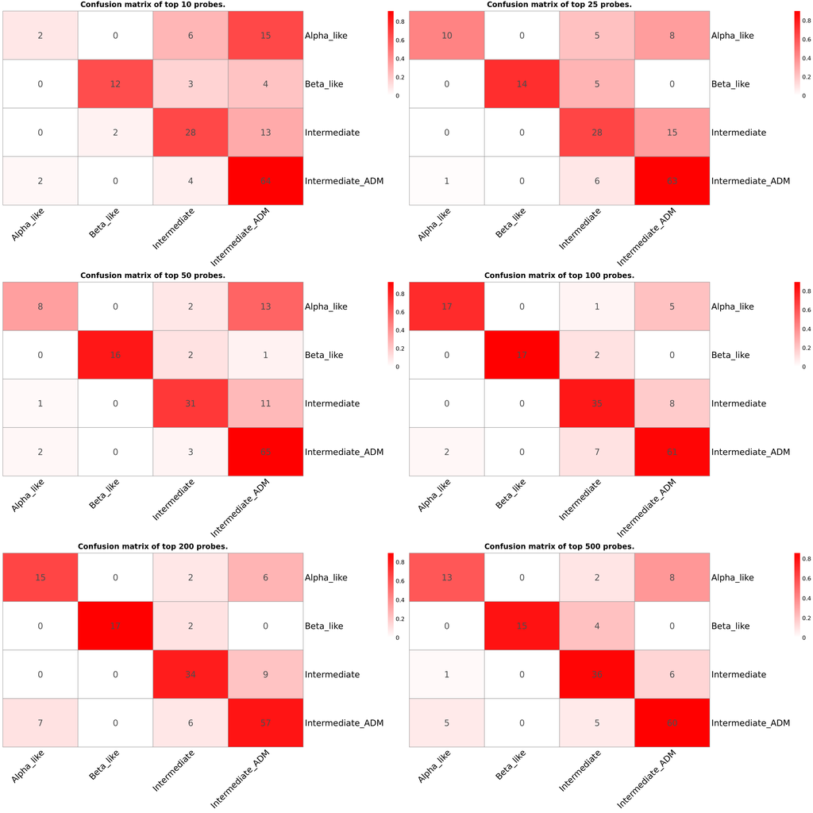

```r
library("grid")
library("gridExtra")
library("pheatmap")
library("ggplot2")

grid.arrange(grobs=list(conf_mat_10[[4]],
                        conf_mat_25[[4]],
                        conf_mat_50[[4]],
                        conf_mat_100[[4]],
                        conf_mat_200[[4]],
                        conf_mat_500[[4]]), ncol=2)
```

**For top 10 probes**

```r
require(kableExtra)
probes_10$out %>% kbl %>% kable_styling()
```

|  | auc | misclassification | brier score | logloss |
| --- | --- | --- | --- | --- |
| raw scores | 0.9232529 | 0.2903226 | 0.3894515 | 0.7075181 |
| calibrated scores | 0.9164316 | 0.3161290 | 0.4411007 | 0.8274562 |

**For top 25 probes**

```r
require(kableExtra)
probes_25$out %>% kbl %>% kable_styling()
```

|  | auc | misclassification | brier score | logloss |
| --- | --- | --- | --- | --- |
| raw scores | 0.9337018 | 0.2387097 | 0.3795780 | 0.6961256 |
| calibrated scores | 0.9269365 | 0.2580645 | 0.3697413 | 0.6866955 |

**For top 50 probes**

```r
require(kableExtra)
probes_50$out %>% kbl %>% kable_styling()
```

|  | auc | misclassification | brier score | logloss |
| --- | --- | --- | --- | --- |
| raw scores | 0.9491980 | 0.2129032 | 0.3595471 | 0.6730384 |
| calibrated scores | 0.9385777 | 0.2258065 | 0.3476981 | 0.6627763 |

**For top 100 probes**

```r
require(kableExtra)
probes_100$out %>% kbl %>% kable_styling()
```

|  | auc | misclassification | brier score | logloss |
| --- | --- | --- | --- | --- |
| raw scores | 0.9679969 | 0.1806452 | 0.3423449 | 0.6554467 |
| calibrated scores | 0.9641062 | 0.1612903 | 0.2831099 | 0.5423084 |

**For top 200 probes**

```r
require(kableExtra)
probes_200$out %>% kbl %>% kable_styling()
```

|  | auc | misclassification | brier score | logloss |
| --- | --- | --- | --- | --- |
| raw scores | 0.9587547 | 0.1870968 | 0.3616963 | 0.6862699 |
| calibrated scores | 0.9492431 | 0.2064516 | 0.2893853 | 0.5321383 |

**For top 500 probes**

```r
require(kableExtra)
probes_500$out %>% kbl %>% kable_styling()
```

|  | auc | misclassification | brier score | logloss |
| --- | --- | --- | --- | --- |
| raw scores | 0.9517547 | 0.1741935 | 0.3640777 | 0.6987295 |
| calibrated scores | 0.9464898 | 0.2000000 | 0.2935258 | 0.5663119 |

```r
roc_10 <- ROC_graph(probes_10, 10)
roc_25 <- ROC_graph(probes_25, 25)
roc_50 <- ROC_graph(probes_50, 50)
roc_100 <- ROC_graph(probes_100, 100)
roc_200 <- ROC_graph(probes_200, 200)
roc_500 <- ROC_graph(probes_500, 500)
```

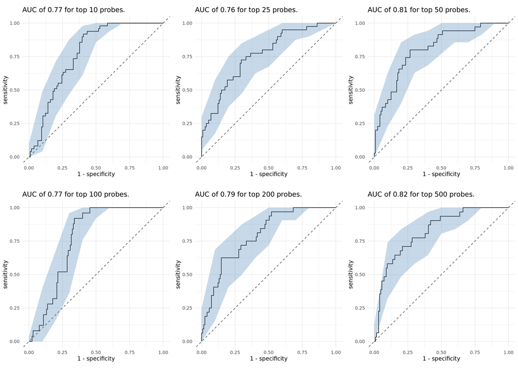

```r
cowplot::plot_grid(roc_10,
                   roc_25,
                   roc_50,
                   roc_100,
                   roc_200,
                   roc_500,
                   ncol =3, align = "v")
```

## 3.1 Score calibration

```r
raw_10 <- raw_score_plot(probes_10)
raw_25 <- raw_score_plot(probes_25)
raw_50 <- raw_score_plot(probes_50)
raw_100 <- raw_score_plot(probes_100)
raw_200 <- raw_score_plot(probes_200)
raw_500 <- raw_score_plot(probes_500)
```

```r
calibrated_10 <- calibrated_score_plot(probes_10)
calibrated_25 <- calibrated_score_plot(probes_25)
calibrated_50 <- calibrated_score_plot(probes_50)
calibrated_100 <- calibrated_score_plot(probes_100)
calibrated_200 <- calibrated_score_plot(probes_200)
calibrated_500 <- calibrated_score_plot(probes_500)
```

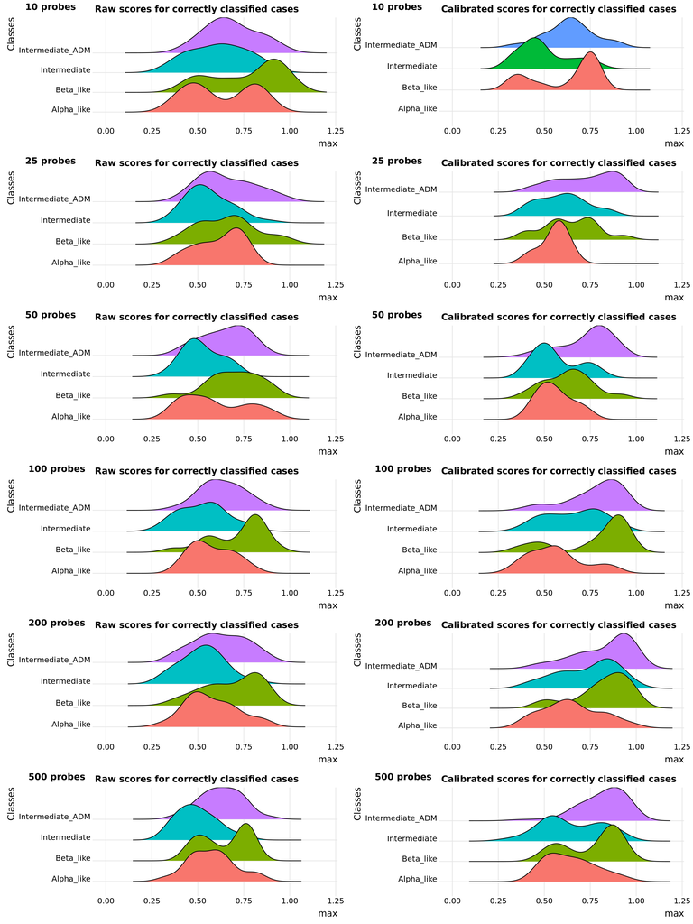

```r
cowplot::plot_grid(raw_10, calibrated_10,
                   raw_25, calibrated_25,
                   raw_50, calibrated_50,
                   raw_100, calibrated_100,
                   raw_200, calibrated_200,
                   raw_500, calibrated_500,
  ncol = 2, labels = c(rep(c("10 probes", "25 probes", "50 probes", "100 probes",
      "200 probes", "500 probes"),each=2)))
```

## 3.2 Consensus clustering

```r
require(pheatmap)
cons_cluster <- readRDS(file = "./data/raw_data/220609_NDD.consClust_DMP.Rds")
cons_cluster <- cons_cluster[[4]]
```

```r
plotCCheatmap = function(ccObject, metaData, previousCC = NULL, colorList){
  ccHmap = ccObject$consensusMatrix
  ccDist = ccObject$consensusTree
  ccDist_rev = ccDist
  ccDist_rev$order = rev(ccDist_rev$order)

  attr(ccHmap, "dimnames") = list(names(ccObject$consensusClass),
                                names(ccObject$consensusClass))

  metaData = as.data.frame(metaData)
  if(all.equal(rownames(metaData), as.character(seq_len(nrow(metaData)))))
    rownames(metaData) = metaData$Sample_Name
  metaData = metaData %>%
    dplyr::select(-Sample_Name)
  if(!is.null(previousCC))
    metaData[[previousCC]][is.na(metaData[[previousCC]])] = "new_sample"

  pheatmap(ccHmap,
           scale = "none",
           color = colorRampPalette(c("white", "blue"))(100),
           cluster_rows = ccDist_rev,
           cluster_cols = ccDist,
           show_rownames = F,
           show_colnames = F,
           cellheight = 2,
           cellwidth = 2,
           annotation_col = metaData,
           annotation_colors = colorList)
}
```

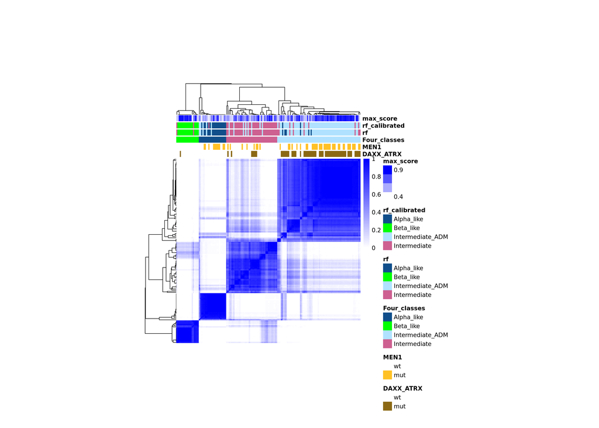

```r
require(dplyr)
meta_data <- read.table(file = "./data/meta_data/training_meta_data_new.txt", sep = "\t", header = T)

scores_plot <- probes_100$scores[meta_data$Sample_Name, ]
meta_data <- cbind(meta_data, colnames(scores_plot)[apply(scores_plot,1,which.max)])
colnames(meta_data)[which(names(meta_data) == "colnames(scores_plot)[apply(scores_plot, 1, which.max)]")] <- "rf"

#now for the calibrated scores
probs_plot <- probes_100$probs[meta_data$Sample_Name, ]
meta_data <- cbind(meta_data, colnames(probs_plot)[apply(probs_plot,1,which.max)])
colnames(meta_data)[which(names(meta_data) == "colnames(probs_plot)[apply(probs_plot, 1, which.max)]")] <- "rf_calibrated"


max_score <- apply(probes_100$probs[meta_data$Sample_Name, ], 1, max)
meta_data <- cbind(meta_data, max_score)


plotCCheatmap(cons_cluster,
              metaData = meta_data %>%
                dplyr::select(Sample_Name,
                              DAXX_ATRX,
                              MEN1,
                              Four_classes,
                              rf,
                              rf_calibrated,
                              max_score),

              colorList = list(DAXX_ATRX = c(wt = "white", mut = "goldenrod4"),
                               MEN1 = c(wt = "white", mut = "goldenrod1"),
                               ConsClus_k4_UB_UCL_ICGC_Chan = c(Alpha_like = "dodgerblue4",
                                                                Beta_like = "green",
                                                                Intermediate_ADM = "lightskyblue1",
                                                                Intermediate_WT = "darksalmon",
                                                                new_sample = "yellow"),
                               rf = c(Alpha_like = "dodgerblue4",
                                                 Beta_like = "green",
                                                 Intermediate_ADM = "lightskyblue1",
                                                 Intermediate = "hotpink3"),
                               rf_calibrated = c(Alpha_like = "dodgerblue4",
                                                 Beta_like = "green",
                                                 Intermediate_ADM = "lightskyblue1",
                                                 Intermediate = "hotpink3"),
                               Four_classes = c(Alpha_like = "dodgerblue4",
                                                 Beta_like = "green",
                                                 Intermediate_ADM = "lightskyblue1",
                                                 Intermediate = "hotpink3"),
                               max_score = colorRampPalette(c("white", "blue"))(100)))
```

There is less disagreement between the random forest and the consensus clustering. This is probably due to the fact that the random forest has a bigger sample group per class to train with. Another reason could be that the it is easier to classify the samples since there are only four classes instead of five.

### 3.2.1 Samples difficult to classify

We then checked for the samples that were difficult to classify. To do so, we selected the maximal score uncalibrated of each sample ( *i.e.* the class assigned by the random forest) and looked at if there was another score that was close to that maximimal score (5% of the trees or less, see code below). This would allow to find the samples that are difficult to classify and to be able to further investigate those samples or train the random forest without those samples.

```r
find_maximal_value <- function(row, threshold) {
  # Find maximal value in the row
  max_value <- max(row)

  # Compare other cells to the maximal value
  res <- (abs(row - max_value) <= threshold) & (abs(row - max_value) > 0.0)

  return(res)
}


# Apply the custom function to each row of the dataframe
test <- apply(scores_plot, 1, find_maximal_value, threshold = 0.05)
test <- t(test)

#dim(test[apply(test, 1, function(x) sum(x)!=0),])
print(rownames(test[apply(test, 1, function(x) sum(x)!=0),]))
```

```
##  [1] "ICGC_0427"  "ICGC_0435"  "ITNET_0673" "ITNET_0935" "NE_0012"
##  [6] "UB19"       "UB22"       "UCL22"      "D_MK18"     "D_MK9"
## [11] "WT_MK27"    "aP464"      "aP328"
```

# 4 Probes in DiDomenico paper

```r
require(dplyr)
require(randomForest)
load(file="./out_100_probes_4_classes/rf.pred.RData")
probes <- as.data.frame(rownames(importance(rf.pred, type=1)))
colnames(probes) <- "probes"
final_probes <- unique(c(intersect(alpha_vs_beta$probes, probes$probes),
                  intersect(alpha_vs_intermediate$probes, probes$probes),
                  intersect(intermediate_vs_beta$probes, probes$probes))
                  )
```

```r
require(kableExtra)
probe.features[final_probes, ] %>% kbl %>% kable_styling()
```

|  | CHR | MAPINFO | Strand | Type | gene | feature | cgi | feat.cgi | UCSC_CpG_Islands_Name | DHS | Enhancer |
| --- | --- | --- | --- | --- | --- | --- | --- | --- | --- | --- | --- |
| cg01602153 | 8 | 59058660 | R | I | FAM110B | 5’UTR | island | 5’UTR-island | chr8:59058167-59059414 | TRUE | TRUE |
| cg00572089 | 12 | 33750494 | R | II |  | IGR | opensea | IGR-opensea |  | NA | TRUE |
| cg03626024 | 12 | 108524345 | F | II | WSCD2 | 5’UTR | shore | 5’UTR-shore | chr12:108522950-108523852 | NA | NA |
| cg24842260 | 10 | 77164147 | R | I | C10orf41 | Body | island | Body-island | chr10:77155128-77169600 | NA | NA |
| cg01557738 | 22 | 49812057 | F | I |  | IGR | island | IGR-island | chr22:49811997-49812468 | NA | NA |
| cg03548857 | 19 | 35940174 | R | II | FFAR2 | TSS1500 | opensea | TSS1500-opensea |  | NA | NA |
| cg05290274 | 17 | 39534096 | F | II | KRT34 | 3’UTR | opensea | 3’UTR-opensea |  | NA | NA |

Interestingly, the DMPs chosen by the classifier are completely different than the ones in the 5 classes case.

# 5 Predicting new data

```r
rm(list=ls())
require(kableExtra)
require(randomForest)
require(dplyr)

test_beta <- readRDS(file = "./data/results/test_beta.Rds")
meta_data <- read.table(file="./data/meta_data/test_EPIC_meta_data.txt", sep = "\t", header = T)
load(file="./out_100_probes_4_classes/rf.pred.RData")
beta <- t(test_beta)
probes <- rownames(importance(rf.pred, importance=1))
beta <- beta[, probes]
answer <- predict(rf.pred, beta, type = "prob")

prediction <- colnames(answer)[apply(answer, 1, which.max)]
answer <- cbind(answer, prediction)

four_classes <- meta_data$CC_Epi_newG1G2_plus_met
four_classes[four_classes=="Intermediate_WT"] <- "Intermediate"
four_classes[four_classes=="Intermediate_ADM_WT"] <- "Intermediate"
meta_data["CC_Epi_newG1G2_individual"] <- four_classes
CC_epi_four_classes <- meta_data$CC_Epi_newG1G2_individual
answer <- cbind(answer, CC_epi_four_classes)

answer <- as.data.frame(answer)

print(sum(answer$prediction==answer$CC_epi_four_classes)/dim(answer)[1])
```

```
## [1] 0.8461538
```

Here accuracy is much higher than for the 5 classes. The reason could be that the joining of two classes improved a lot the accuracy of the random forest. It could also be possible that the fact of joining two classes increases the chances of assigning a sample at random and being correct.

```r
answer[answer$prediction!=answer$CC_epi,] %>% kbl %>% kable_styling()
```

|  | Alpha_like | Beta_like | Intermediate | Intermediate_ADM | prediction | CC_epi_four_classes |
| --- | --- | --- | --- | --- | --- | --- |
| aP476m | 0.256 | 0.136 | 0.348 | 0.26 | Intermediate | Intermediate_ADM |
| aP494p | 0.088 | 0.104 | 0.354 | 0.454 | Intermediate_ADM | Intermediate |
| mP072p | 0.248 | 0.186 | 0.208 | 0.358 | Intermediate_ADM | Alpha_like |
| aP471m2 | 0.112 | 0.188 | 0.308 | 0.392 | Intermediate_ADM | Intermediate |
| mP068p | 0.088 | 0.376 | 0.348 | 0.188 | Beta_like | Intermediate |
| aP494m | 0.066 | 0.114 | 0.342 | 0.478 | Intermediate_ADM | Intermediate |

As accuracy showed, there is less disagreement in the 4 classes than in the 5 classes case.